# Part I - (Prosper Loan Data Exploration)

## Introduction

This document explores a dataset containing 113,937 loans with 81 variables on each of loan,including loan amount,borrower rate(or interest rate),current loan status,borrower income and many others.

## Preliminary Wrangling

```python
# import all packages and set plots to be embedded inline
import numpy as np
import pandas as pd
import matplotlib.pyplot as plt
import seaborn as sb

%matplotlib inline
```

```python
#load in the dataset into a pandas dataframe
prosper_loan = pd.read_csv('prosperLoanData.csv')
```

```python
#high-level overview of data and composition
print(prosper_loan.shape)
print(prosper_loan.dtypes)
print(prosper_loan.head(10))
```

```
(113937, 81)
ListingKey                              object
ListingNumber                            int64
ListingCreationDate                     object
CreditGrade                             object
Term                                     int64
LoanStatus                              object
ClosedDate                              object
BorrowerAPR                            float64
BorrowerRate                           float64
LenderYield                            float64
EstimatedEffectiveYield                float64
EstimatedLoss                          float64
EstimatedReturn                        float64
ProsperRating (numeric)                float64
ProsperRating (Alpha)                   object
ProsperScore                           float64
ListingCategory (numeric)                int64
BorrowerState                           object
Occupation                              object
EmploymentStatus                        object
EmploymentStatusDuration               float64
IsBorrowerHomeowner                       bool
CurrentlyInGroup                          bool
GroupKey                                object
DateCreditPulled                        object
CreditScoreRangeLower                  float64
CreditScoreRangeUpper                  float64
FirstRecordedCreditLine                 object
CurrentCreditLines                     float64
OpenCreditLines                        float64
                                        ...
TotalProsperLoans                      float64
TotalProsperPaymentsBilled             float64
OnTimeProsperPayments                  float64
ProsperPaymentsLessThanOneMonthLate    float64
ProsperPaymentsOneMonthPlusLate        float64
ProsperPrincipalBorrowed               float64
ProsperPrincipalOutstanding            float64
ScorexChangeAtTimeOfListing            float64
```

[output cut: 81 more lines]

```
9            1.0                0                          0

  InvestmentFromFriendsAmount Investors
0                         0.0       258
1                         0.0         1
2                         0.0        41
3                         0.0       158
4                         0.0        20
5                         0.0         1
6                         0.0         1
7                         0.0         1
8                         0.0         1
9                         0.0         1

[10 rows x 81 columns]
```

```python
#create a dataframe from our main variable of interest, LoanStatus for Defaulted,Completed,Chargedoff
prosper_loan_df = prosper_loan.loc[prosper_loan['LoanStatus'].isin(['Defaulted','Completed','Chargedoff'])]
```

```python
#lets create a column CreditScoreMean
prosper_loan_df['CreditScoreMean'] = prosper_loan_df[['CreditScoreRangeLower', 'CreditScoreRangeUpper']].mean(axis=1)
```

```python
#lets clean the ProsperScore column
prosper_loan_df['ProsperScore'].isnull().sum()
```

```
29079
```

```python
#lets drop the null values in ProsperScore
prosper_loan_df['ProsperScore'].dropna(inplace=True)
```

```python
#lets replace the null values in CreditScoreMean column with the mean
prosper_loan_df['CreditScoreMean'].fillna(int(prosper_loan_df['CreditScoreMean'].mean()), inplace=True)
```

```python
#find the descriptive statistics for the numeric variables
prosper_loan.describe()
```

|  | ListingNumber | Term | BorrowerAPR | BorrowerRate | LenderYield | EstimatedEffectiveYield | EstimatedLoss | EstimatedReturn | ProsperRating (numeric) | ProsperScore | ... | LP_ServiceFees | LP_CollectionFees | LP_GrossPrincipalLoss | LP_NetPrincipalLoss | LP_NonPrincipalRecoverypayments | PercentFunded | Recommendations | InvestmentFromFriendsCount | InvestmentFromFriendsAmount | Investors |
| --- | --- | --- | --- | --- | --- | --- | --- | --- | --- | --- | --- | --- | --- | --- | --- | --- | --- | --- | --- | --- | --- |
| count | 1.139370e+05 | 113937.000000 | 113912.000000 | 113937.000000 | 113937.000000 | 84853.000000 | 84853.000000 | 84853.000000 | 84853.000000 | 84853.000000 | ... | 113937.000000 | 113937.000000 | 113937.000000 | 113937.000000 | 113937.000000 | 113937.000000 | 113937.000000 | 113937.000000 | 113937.000000 | 113937.000000 |
| mean | 6.278857e+05 | 40.830248 | 0.218828 | 0.192764 | 0.182701 | 0.168661 | 0.080306 | 0.096068 | 4.072243 | 5.950067 | ... | -54.725641 | -14.242698 | 700.446342 | 681.420499 | 25.142686 | 0.998584 | 0.048027 | 0.023460 | 16.550751 | 80.475228 |
| std | 3.280762e+05 | 10.436212 | 0.080364 | 0.074818 | 0.074516 | 0.068467 | 0.046764 | 0.030403 | 1.673227 | 2.376501 | ... | 60.675425 | 109.232758 | 2388.513831 | 2357.167068 | 275.657937 | 0.017919 | 0.332353 | 0.232412 | 294.545422 | 103.239020 |
| min | 4.000000e+00 | 12.000000 | 0.006530 | 0.000000 | -0.010000 | -0.182700 | 0.004900 | -0.182700 | 1.000000 | 1.000000 | ... | -664.870000 | -9274.750000 | -94.200000 | -954.550000 | 0.000000 | 0.700000 | 0.000000 | 0.000000 | 0.000000 | 1.000000 |
| 25% | 4.009190e+05 | 36.000000 | 0.156290 | 0.134000 | 0.124200 | 0.115670 | 0.042400 | 0.074080 | 3.000000 | 4.000000 | ... | -73.180000 | 0.000000 | 0.000000 | 0.000000 | 0.000000 | 1.000000 | 0.000000 | 0.000000 | 0.000000 | 2.000000 |
| 50% | 6.005540e+05 | 36.000000 | 0.209760 | 0.184000 | 0.173000 | 0.161500 | 0.072400 | 0.091700 | 4.000000 | 6.000000 | ... | -34.440000 | 0.000000 | 0.000000 | 0.000000 | 0.000000 | 1.000000 | 0.000000 | 0.000000 | 0.000000 | 44.000000 |
| 75% | 8.926340e+05 | 36.000000 | 0.283810 | 0.250000 | 0.240000 | 0.224300 | 0.112000 | 0.116600 | 5.000000 | 8.000000 | ... | -13.920000 | 0.000000 | 0.000000 | 0.000000 | 0.000000 | 1.000000 | 0.000000 | 0.000000 | 0.000000 | 115.000000 |
| max | 1.255725e+06 | 60.000000 | 0.512290 | 0.497500 | 0.492500 | 0.319900 | 0.366000 | 0.283700 | 7.000000 | 11.000000 | ... | 32.060000 | 0.000000 | 25000.000000 | 25000.000000 | 21117.900000 | 1.012500 | 39.000000 | 33.000000 | 25000.000000 | 1189.000000 |

8 rows × 61 columns

```python
#convert Occupation to Categorical variables
var_dict = {'Occupation': ['Accountant/CPA', 'Administrative Assistant', 'Analyst', 'Architect',
        'Attorney', 'Biologist', 'Bus Driver', 'Car Dealer', 'Chemist', 'Civil Service',
        'Clergy', 'Clerical', 'Computer Programmer', 'Construction', 'Dentist', 'Doctor',
         'Engineer - Mechanical', 'Engineer - Electrical', 'Engineer-Mechanical', 'Executive',
         'Fireman', 'Filght Attendant', 'Food Service', 'Food Service Management', 'Homemaker',
         'Investor', 'Judge', 'Laborer', 'Landscaping', 'Medical Technician', 'Military Enlisted',
        'Military Officer', 'Nurse (LPN)', 'Nurse (RN)', "Nurse's Aid", 'Other', 'Pharmacist',
         'Pilot - Private/Commercial', 'Police Officer/Correction Officer', 'Postal Service',
         'Principal', 'Professional', 'Professor', 'Psychologist', 'Realtor', 'Religious',
          'Retail Management', 'Sales - Commission', 'Sales - Retail', 'Scientist', 'Skilled Labor',
         ' Social Worker', 'Student - College Freshman', 'Student - College Graduate Student',
         'Student - College Junior', 'Student - College Senior', 'Student - College Sophomore',
        'Student - Community College', 'Student - Technical School', 'Teacher', "Teacher's Aide",
        'Tradesman - Carpenter', 'Tradesman - Electrician', 'Tradesman - Mechanic', 'Tradesman - Plumber',
        'Truck Driver', 'Waiter/Waitress']}

for var in var_dict:
    ordered_var = pd.api.types.CategoricalDtype(ordered = True,
                                                categories = var_dict[var])
    prosper_loan[var] = prosper_loan[var].astype(ordered_var)
```

```python
#check the variable type in Occupation to confirm
prosper_loan['Occupation'].dtype
```

```
CategoricalDtype(categories=['Accountant/CPA', 'Administrative Assistant', 'Analyst',
                  'Architect', 'Attorney', 'Biologist', 'Bus Driver',
                  'Car Dealer', 'Chemist', 'Civil Service', 'Clergy',
                  'Clerical', 'Computer Programmer', 'Construction', 'Dentist',
                  'Doctor', 'Engineer - Mechanical', 'Engineer - Electrical',
                  'Engineer-Mechanical', 'Executive', 'Fireman',
                  'Filght Attendant', 'Food Service',
                  'Food Service Management', 'Homemaker', 'Investor', 'Judge',
                  'Laborer', 'Landscaping', 'Medical Technician',
                  'Military Enlisted', 'Military Officer', 'Nurse (LPN)',
                  'Nurse (RN)', 'Nurse's Aid', 'Other', 'Pharmacist',
                  'Pilot - Private/Commercial',
                  'Police Officer/Correction Officer', 'Postal Service',
                  'Principal', 'Professional', 'Professor', 'Psychologist',
                  'Realtor', 'Religious', 'Retail Management',
                  'Sales - Commission', 'Sales - Retail', 'Scientist',
                  'Skilled Labor', ' Social Worker',
                  'Student - College Freshman',
                  'Student - College Graduate Student',
                  'Student - College Junior', 'Student - College Senior',
                  'Student - College Sophomore', 'Student - Community College',
                  'Student - Technical School', 'Teacher', 'Teacher's Aide',
                  'Tradesman - Carpenter', 'Tradesman - Electrician',
                  'Tradesman - Mechanic', 'Tradesman - Plumber',
                  'Truck Driver', 'Waiter/Waitress'],
                 ordered=True)
```

### What is/are the main feature(s) of interest in your dataset?

My main interest is to determine the features that are responsible in predicting LoanStatus.Further,to specifically find out the features responsible in determining whether a Loan will be defaulted, completed or chargedoff.

### What features in the dataset do you think will help support your investigation into your feature(s) of interest?

My expectations are that IncomeVerifiable,ProsperScore,BorrowerState and the EmploymentStatus variables will be the determining variables in regards to predicting LoanStatus. However, i consider other variables to help support my investigation. The variables include the following:

- ListingCategory (numeric)
- Prosper Score
- CreditScoreMean(To be derived from the average of CreditScoreRangeUpper and CreditScoreRangeLower)
- EmploymentStatus
- IsBorrowerHomeowner
- Occupation
- IncomeVerifiable
- BorrowerState
- MonthlyLoanPayment
- Term

## Univariate Exploration

I'll start by lookking at my main variable of interest, LoanStatus and proceed futher to investigate the other variables listed above.

```python
#check the variables in LoanStatus (numeric)
prosper_loan['LoanStatus'].unique()
```

```
array(['Completed', 'Current', 'Past Due (1-15 days)', 'Defaulted',
       'Chargedoff', 'Past Due (16-30 days)', 'Cancelled',
       'Past Due (61-90 days)', 'Past Due (31-60 days)',
       'Past Due (91-120 days)', 'FinalPaymentInProgress',
       'Past Due (>120 days)'], dtype=object)
```

### LoanStatus

#### Question : What is the distribution of LoanStatus under Defaulted,Completed and Chargedoff Status?

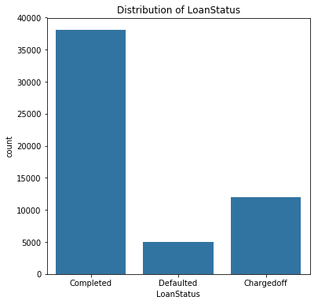

```python
#check the distribution of LoanStatus specifically for defaulted,completed and charged statuses.
prosper_loan_df = prosper_loan.loc[prosper_loan['LoanStatus'].isin(['Defaulted','Completed','Chargedoff'])]
plt.figure(figsize = (6,6))
base_color = sb.color_palette()[0]
sb.countplot(data=prosper_loan_df, x='LoanStatus', color=base_color)
plt.title('Distribution of LoanStatus');
```

I have chosen a barchart for plotting since the LoanStatus variable is Categrocial. It is clear from the visual that a huge nnumber of loans were completed with few loans defaulted.

### ListingCategory (numeric)

#### Question : How is the ListingCategory (numeric) variable distributed?

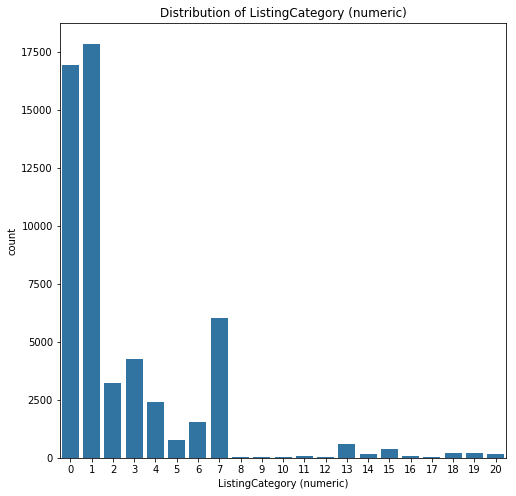

```python
plt.figure(figsize = (8,8))
sb.countplot(data=prosper_loan_df, x='ListingCategory (numeric)', color=base_color)
plt.title('Distribution of ListingCategory (numeric)');
```

```python
#ListingCategory appears to be a categorical variable.Let's convert it to a categorical variable
list_cat = ['Not Available', 'Debt Consolidation', 'Home Improvement', 'Business', 'Personal Loan', 'Student Use', 'Auto', 'Other',
          'Baby&Adoption', 'Boat', 'Cosmetic Procedure', 'Engagement Ring', 'Green Loans', 'Household Expenses', 'Large Purchases',
          'Medical/Dental', 'Motorcycle', 'RV', 'Taxes', 'Vacation', 'Wedding Loans']
prosper_loan_df['ListingCategory (numeric)'] = prosper_loan_df['ListingCategory (numeric)'].apply(lambda i : list_cat[i])
```

```python
prosper_loan_df['ListingCategory (numeric)'].unique()
```

```
array(['Not Available', 'Household Expenses', 'Medical/Dental',
       'Debt Consolidation', 'Wedding Loans', 'Other', 'Vacation', 'Auto',
       'Business', 'Taxes', 'Personal Loan', 'Home Improvement',
       'Student Use', 'Motorcycle', 'Engagement Ring', 'Large Purchases',
       'Cosmetic Procedure', 'Boat', 'RV', 'Baby&Adoption', 'Green Loans'], dtype=object)
```

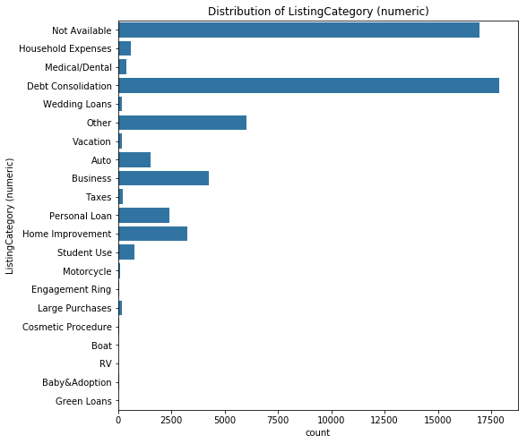

```python
#plot horizontally and observe the distributions

plt.figure(figsize = (8,8))
sb.countplot(data = prosper_loan_df, y='ListingCategory (numeric)', color=base_color)
plt.title('Distribution of ListingCategory (numeric)');
```

The appropriate plot for ListingCategory (numeric) is a barplot because the latter variable is categorical. We can see from the figure that most of the loans were used for Debt Consolidation immediately followed by loans whose purpose was not indicated i.e Not Available

### ProsperScore

#### Question : What is the distribution of ProsperScore?

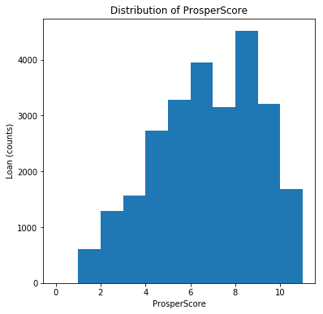

```python
#let us plot the distribution of the variable ProsperScore
#lets drop the null values in ProsperScore
prosper_loan_df['ProsperScore'].dropna(inplace=True)
plt.figure(figsize = (6,6))
bins = np.arange(0,prosper_loan_df['ProsperScore'].max()+1 , 1)
base_color = sb.color_palette()[0]
plt.hist(data=prosper_loan_df, x='ProsperScore', color=base_color, bins=bins)
plt.xlabel('ProsperScore')
plt.ylabel('Loan (counts)')
plt.title('Distribution of ProsperScore');
```

### CreditScoreMean

#### Question : How is CreditScoreMean distributed?

```python
#lets create a column CreditScoreMean
prosper_loan_df['CreditScoreMean'] = prosper_loan_df[['CreditScoreRangeLower', 'CreditScoreRangeUpper']].mean(axis=1)
```

```python
prosper_loan_df.columns
```

```
Index(['ListingKey', 'ListingNumber', 'ListingCreationDate', 'CreditGrade',
       'Term', 'LoanStatus', 'ClosedDate', 'BorrowerAPR', 'BorrowerRate',
       'LenderYield', 'EstimatedEffectiveYield', 'EstimatedLoss',
       'EstimatedReturn', 'ProsperRating (numeric)', 'ProsperRating (Alpha)',
       'ProsperScore', 'ListingCategory (numeric)', 'BorrowerState',
       'Occupation', 'EmploymentStatus', 'EmploymentStatusDuration',
       'IsBorrowerHomeowner', 'CurrentlyInGroup', 'GroupKey',
       'DateCreditPulled', 'CreditScoreRangeLower', 'CreditScoreRangeUpper',
       'FirstRecordedCreditLine', 'CurrentCreditLines', 'OpenCreditLines',
       'TotalCreditLinespast7years', 'OpenRevolvingAccounts',
       'OpenRevolvingMonthlyPayment', 'InquiriesLast6Months', 'TotalInquiries',
       'CurrentDelinquencies', 'AmountDelinquent', 'DelinquenciesLast7Years',
       'PublicRecordsLast10Years', 'PublicRecordsLast12Months',
       'RevolvingCreditBalance', 'BankcardUtilization',
       'AvailableBankcardCredit', 'TotalTrades',
       'TradesNeverDelinquent (percentage)', 'TradesOpenedLast6Months',
       'DebtToIncomeRatio', 'IncomeRange', 'IncomeVerifiable',
       'StatedMonthlyIncome', 'LoanKey', 'TotalProsperLoans',
       'TotalProsperPaymentsBilled', 'OnTimeProsperPayments',
       'ProsperPaymentsLessThanOneMonthLate',
       'ProsperPaymentsOneMonthPlusLate', 'ProsperPrincipalBorrowed',
       'ProsperPrincipalOutstanding', 'ScorexChangeAtTimeOfListing',
       'LoanCurrentDaysDelinquent', 'LoanFirstDefaultedCycleNumber',
       'LoanMonthsSinceOrigination', 'LoanNumber', 'LoanOriginalAmount',
       'LoanOriginationDate', 'LoanOriginationQuarter', 'MemberKey',
       'MonthlyLoanPayment', 'LP_CustomerPayments',
       'LP_CustomerPrincipalPayments', 'LP_InterestandFees', 'LP_ServiceFees',
       'LP_CollectionFees', 'LP_GrossPrincipalLoss', 'LP_NetPrincipalLoss',
       'LP_NonPrincipalRecoverypayments', 'PercentFunded', 'Recommendations',
       'InvestmentFromFriendsCount', 'InvestmentFromFriendsAmount',
       'Investors', 'CreditScoreMean'],
      dtype='object')
```

```python
#check the statistics to calculate bins
prosper_loan_df['CreditScoreMean'].describe()
```

```
count    54494.000000
mean       681.246247
std         81.908137
min          9.500000
25%        649.500000
50%        689.500000
75%        729.500000
max        889.500000
Name: CreditScoreMean, dtype: float64
```

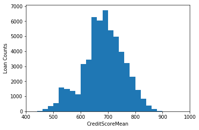

```python
#lets replace the null values in CreditScoreMean column with the mean
prosper_loan_df['CreditScoreMean'].fillna(int(prosper_loan_df['CreditScoreMean'].mean()), inplace=True)
bins = np.arange(0, prosper_loan_df['CreditScoreMean'].max()+20, 20)
base_color = sb.color_palette()[0]
plt.hist(data=prosper_loan_df, x='CreditScoreMean', bins=bins)
plt.xlabel('CreditScoreMean')
plt.ylabel('Loan Counts')
plt.xlim((400,1000));
```

The plot that is appropriate here is the histogram due to the numerical nature of the CreditScoreMean variable. Our data is normally distributed as wecan see from the plot. The peak of the plot shows the highest concentration of the credit scores for borrowers which is approximately 700. This is similar to ProsperScore rating where the mode was between 6 and 8.5 which a good rating.

### Term

#### Question : How is the loan Term period distributed|?

```python
prosper_loan_df.Term.describe()
```

```
count    55084.000000
mean        36.942851
std          7.333480
min         12.000000
25%         36.000000
50%         36.000000
75%         36.000000
max         60.000000
Name: Term, dtype: float64
```

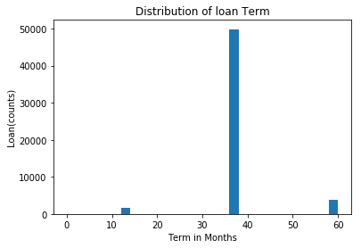

```python
#lets plot the distribution of Term
bins = np.arange(0, prosper_loan_df['Term'].max()+2, 2)
plt.hist(data=prosper_loan_df, x='Term', color=base_color, bins=bins)
plt.xlabel('Term in Months')
plt.ylabel('Loan(counts)')
plt.title('Distribution of loan Term');
```

The Term variable has been divided into 3 periods: 12, 36, and 60 months. We can see from our histogram plot that majority of the borrowers are opting for the 36 months loan repayment period.

### Occupation

#### Question : How is Occupation distributed?

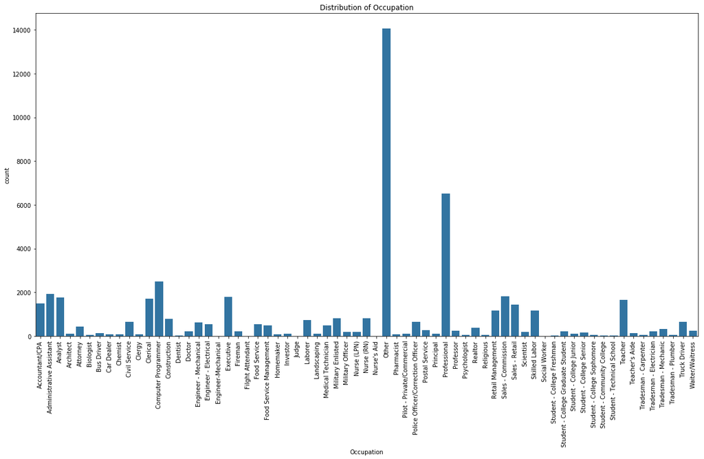

```python
#lets plot the distribution of Occupation
plt.figure(figsize = (20,10))
sb.countplot(data=prosper_loan_df, x='Occupation', color=base_color)
plt.xticks(rotation=90)
plt.title('Distribution of Occupation');
```

### EmploymentStatus

#### Question : What is the distribution of EmploymentStatus?

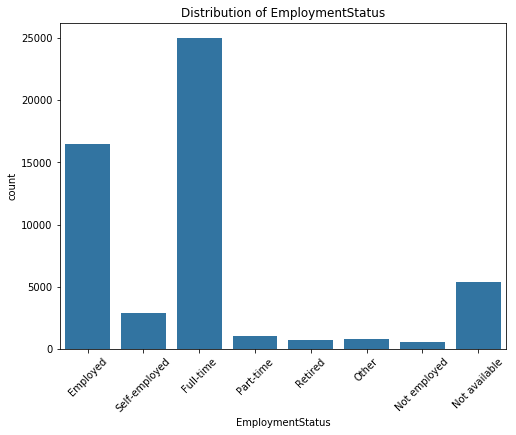

```python
emp_order = ['Employed','Self-employed','Full-time','Part-time','Retired','Other','Not employed', 'Not available']
ordered_var = pd.api.types.CategoricalDtype(ordered = True,
                                    categories = emp_order)
prosper_loan_df['EmploymentStatus'] = prosper_loan_df['EmploymentStatus'].astype(ordered_var)

plt.figure(figsize = (8,6))
sb.countplot(data=prosper_loan_df, x='EmploymentStatus', color=base_color)
plt.xticks(rotation=45)
plt.title('Distribution of EmploymentStatus');
```

The barplot clearly indicates that most of the borrowers are employed with majority employed full time.

### IsBorrowerHomeowner

#### Question : How is IsBorrowerHomeowner distributed?

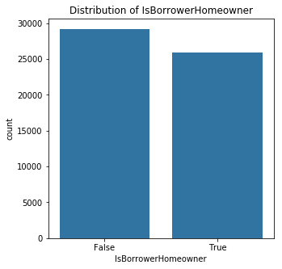

```python
plt.figure(figsize = (5,5))
sb.countplot(data=prosper_loan_df, x='IsBorrowerHomeowner', color=base_color)
plt.title('Distribution of IsBorrowerHomeowner');
```

The plot clearly depicts that most of the borrowers are not actually homeowners

### IncomeVerifiable

#### Question : What is the distribution of IncomeVerifiable?

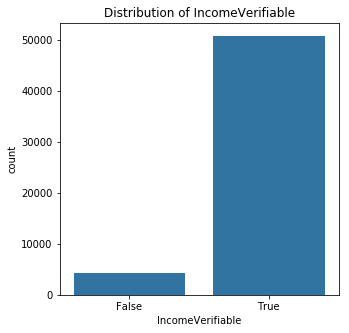

```python
plt.figure(figsize = (5,5))
sb.countplot(data=prosper_loan_df, x='IncomeVerifiable', color=base_color)
plt.title('Distribution of IncomeVerifiable');
```

It is evident from the plot that majority of the borrowers have verifiable income.

### BorrowerState

#### Question : How is BorrowerState distributed?

```
Text(0.5,1,'Distribution of BorrowerState')
```

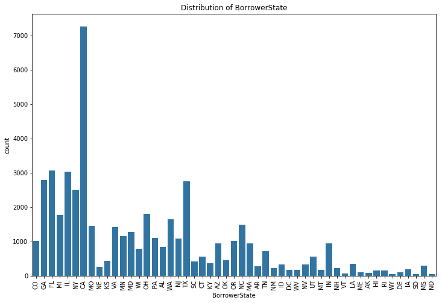

```python
plt.figure(figsize = (12,8))
sb.countplot(data=prosper_loan_df, x='BorrowerState', color=base_color)
plt.xticks(rotation=90)
plt.title('Distribution of BorrowerState')
```

Most of the borrowers are from the states of California, Florida, Illnois and Texas as is evident from the plot.

### MonthlyLoanPayment

#### What is the distribution of MonthlyLoanPayment?

```python
#check the descriptive statistics to calculate bins
prosper_loan_df['MonthlyLoanPayment'].describe()
```

```
count    55084.000000
mean       223.729882
std        185.727523
min          0.000000
25%         98.290000
50%        172.600000
75%        300.472500
max       2251.510000
Name: MonthlyLoanPayment, dtype: float64
```

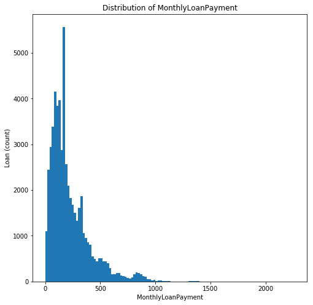

```python
plt.figure(figsize = (8,8))
bins = np.arange(0, prosper_loan_df['MonthlyLoanPayment'].max()+20, 20)
plt.hist(data=prosper_loan_df, x='MonthlyLoanPayment', color=base_color, bins=bins)
plt.title('Distribution of MonthlyLoanPayment')
plt.xlabel('MonthlyLoanPayment')
plt.ylabel('Loan (count)');
```

It is clear from the plot that most of the Monthly Loan Payments fall below 500 which seems sustainable.

### Discuss the distribution(s) of your variable(s) of interest. Were there any unusual points? Did you need to perform any transformations?

> The main variable of interest in this exploration is LoanStatus. I am more interested in the Defaulted, Completed and Chargedoff categories. In this regards, i sliced these categories to my dataframe where it is observed that most of the loans were in Complete status with very few Defaulted. There were however no unsual points noted.

### Of the features you investigated, were there any unusual distributions? Did you perform any operations on the data to tidy, adjust, or change the form of the data? If so, why did you do this?

> Majority of the features i investigated were usual distributions but however i had to make a bit of adjustments with my dataset as follows:
> - Converted the ListingCategory col to a category datatype
> - Changed numerical value to the category they were given with the definition provided
> - Created a column CreditScoreMean from the average of CreditScoreRangeUpper and CreditScoreRangeLower
> - Converted Occupation to a categorical variable
> - Filled the missing values with the mean in the CredtScoreMean column
> - Added an x-axis scale limit to CreditScoreMean ditribution to focus on the data

## Bivariate Exploration

> I will by investigating the correlation of the numeric variables in my dataset

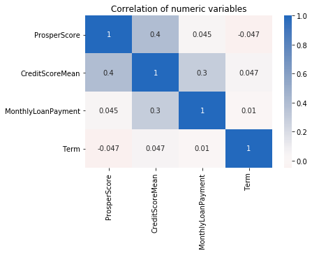

```python
num_vars = ['ProsperScore','CreditScoreMean','MonthlyLoanPayment','Term']
sb.heatmap(data= prosper_loan_df[num_vars].corr(), annot=True, cmap='vlag_r', center=0)
plt.title('Correlation of numeric variables');
```

#### Question : What is the relationship of LoanStatus and EmploymentStatus?

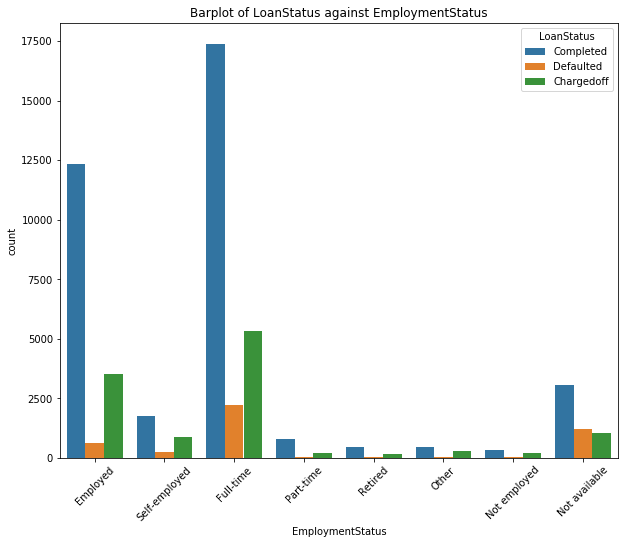

```python
plt.figure(figsize = (10,8))
sb.countplot(data = prosper_loan_df, x = 'EmploymentStatus', hue = 'LoanStatus')
plt.xticks(rotation=45)
plt.title('Barplot of LoanStatus against EmploymentStatus');
```

The barchart shows clearly that the Completed loans were the highest and this was attributed to those with a full time employment followed by those that are employed. Most of the loans were discharged off than defaulted except for the category where employment details are not available.

#### Question : What is the relationship between LoanStatus and IncomeVerifiable

```python
#use groupby to create a series of LoanStatus and IncomeVerfiable
ct_counts = prosper_loan_df.groupby(['LoanStatus','IncomeVerifiable']).size()
```

```python
ct_counts.head()
```

```
LoanStatus  IncomeVerifiable
Chargedoff  False                1260
            True                10732
Completed   False                2782
            True                35292
Defaulted   False                 258
dtype: int64
```

```python
# Use Series.reset_index() to convert a series into a dataframe object
ct_counts = ct_counts.reset_index(name='count')
```

```python
#use pivot function to rearrange the data to have the LoanStatus on rows
ct_counts = ct_counts.pivot(index = 'LoanStatus', columns = 'IncomeVerifiable', values = 'count')
```

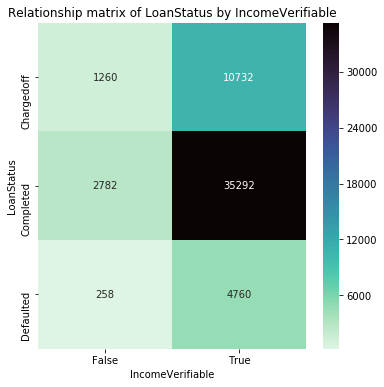

```python
plt.figure(figsize = (6,6))
sb.heatmap(data=ct_counts, annot = True, fmt='.0f', cmap='mako_r')
plt.title('Relationship matrix of LoanStatus by IncomeVerifiable');
```

Generally, there is a high number of borrowers with verifiable incomes. This is also responsible for the high number of completed loans. In other words,the borrowers with verifiable incomes have a high chance of completing their loans.

#### Question : How does ProsperScore relate with LoanStatus?

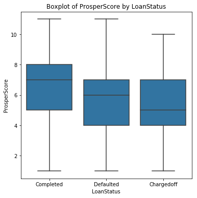

```python
plt.figure(figsize = (6,6))
sb.boxplot(data=prosper_loan_df, x='LoanStatus', y='ProsperScore', color=base_color)
plt.title('Boxplot of ProsperScore by LoanStatus');
```

It is evident from the plot that the Completed loans have the highest median which drops uniformly.The high ProsperScore ratings are associated with completed loans. This implies that the ProsperScores are correct in predicting the LoanStatus with high scores correspodning to loans Completed. However, borrowers with a ProsperScore below those who Defaulted had their loans dischragedoff.

#### Question : What is the relationship between ProsperScore and BorrowerState?

```
Text(0.5,1,'Relationship between ProsperScore and State')
```

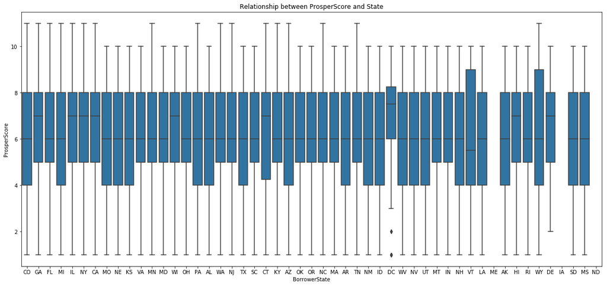

```python
plt.figure(figsize = (20,10))
sb.boxplot(data=prosper_loan_df, x='BorrowerState', y='ProsperScore', color=base_color)
plt.gcf().set_size_inches(20, 9)
plt.title('Relationship between ProsperScore and State')
```

The plot indicates that the States with top ProsperScores are DC,GA,IL,NY,CA,WI,CT,HI, and DE according to their medians. TX which was among the states with high borrowers has a lower ProsperScore.

#### Question : What is the relationship between EmploymentStatus and Incomeverifiable?

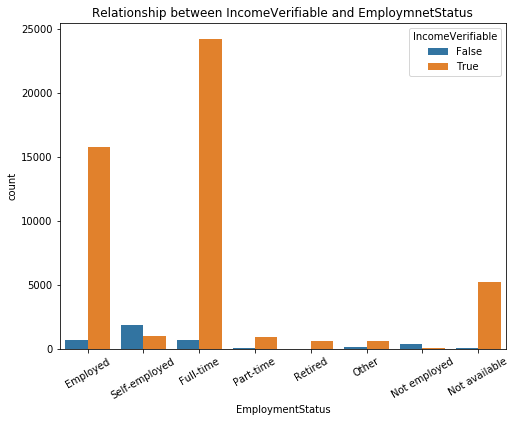

```python
#Lets visualize the two categorical variables using a countplot
plt.figure(figsize = (8,6))
g=sb.countplot(data=prosper_loan_df, x='EmploymentStatus', hue='IncomeVerifiable', orient='v')
plt.xticks(rotation=30)
plt.title('Relationship between IncomeVerifiable and EmploymnetStatus');
```

The visual depicts that the borrowers with full-time employment were the highest with their incomes verifiable followed by those with Employed status

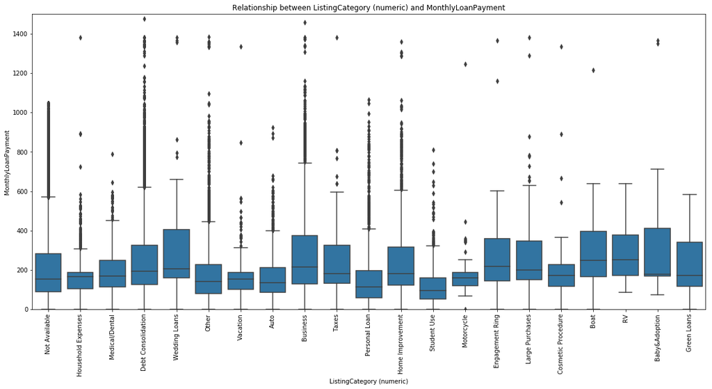

```python
plt.figure(figsize = (8,15))
sb.boxplot(data=prosper_loan_df, x='ListingCategory (numeric)', y='MonthlyLoanPayment', color=base_color)
plt.xticks(rotation=90)
plt.gcf().set_size_inches(20, 9)
plt.ylim(0, 1500)
plt.title('Relationship between ListingCategory (numeric) and MonthlyLoanPayment');
```

The boxplot above shows that Businesses, Wedding Rings, Boat and RV have the highest medians. This means that the latter categories have a high MonthlyLoanPayment.

### Talk about some of the relationships you observed in this part of the investigation. How did the feature(s) of interest vary with other features in the dataset?

In the various relationships between variables, i observed the following relationships between my variables of interest:

- The relationship between EmploymentStatus and LoanStatus informed us that the high full-time and employed borrowers are associated with high number of Completed loans.
- Under LoanStatus and IncomeVerifiable relationship, there is a high number of borrowers with their income verifiable. This is what is responsible for the high number of Completed loans witnessed.
- There is a positive relationship between LoanStatus and ProsperScore with high ProsperScores corresponding to high number of Completed loans.

### Did you observe any interesting relationships between the other features (not the main feature(s) of interest)?

The relationship between ListingCategory (numeric) and MonthlyLoanPayment shows that the categories of Businesses, Wedding Rings, Boat and RV have the highest MonthlyLoanPayment probably because they have extra income at their disposure and source of income for those with businesses.

## Multivariate Exploration

In this section i will continue with my exploration on LoanStatus and EmploymentStatus, and how other variables associate with them.

#### Question : What is the relationship between LoanStatus, EmploymentStatus and ProsperScore?

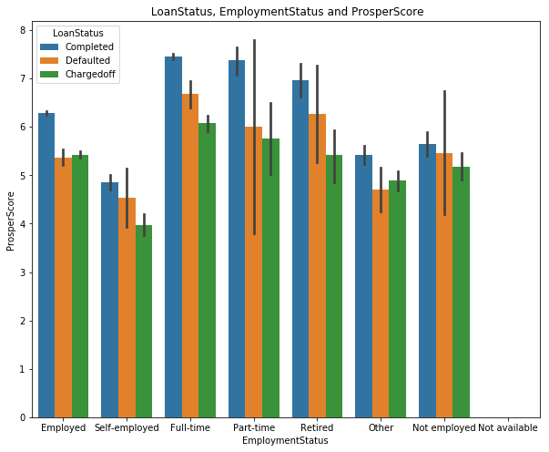

```python
plt.figure(figsize = (10,8))
sb.barplot(data=prosper_loan_df, x='EmploymentStatus', y='ProsperScore', hue='LoanStatus')
plt.title(' LoanStatus, EmploymentStatus and ProsperScore');
```

It is evident from the plot that the borrowers who Completed their loans have a high ProsperScore regardless of their EmploymentStatus. The borrowers with who Defaulted seem to have higher ProsperScores than those with Chragedoff loans which is quite surprising.

#### Question : What is the relationship between LoanStatus, BorrowerState and ProsperScore?

```python
#get the indexes for the top 10 states
prosper_loan_df['BorrowerState'].value_counts()[:10].index
```

```
Index(['CA', 'FL', 'IL', 'GA', 'TX', 'NY', 'OH', 'MI', 'WA', 'NC'], dtype='object')
```

```python
#create a dataframe from our main dataframe to showcase the top 10 states
top10_states = prosper_loan_df.loc[prosper_loan_df['BorrowerState'].isin(['CA', 'FL', 'IL', 'GA', 'TX', 'NY', 'OH', 'MI', 'WA', 'NC'])]
```

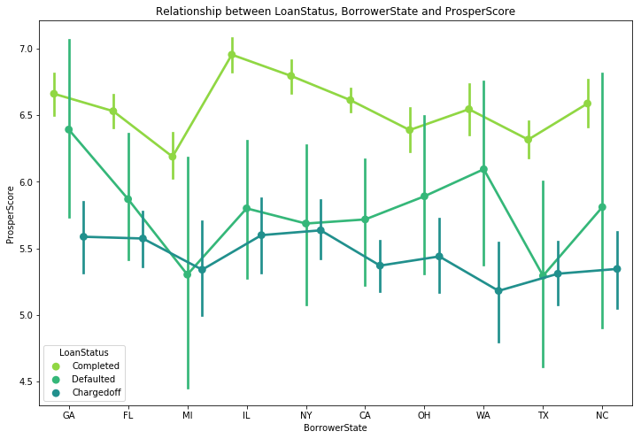

```python
plt.figure(figsize = (12,8))
sb.pointplot(data=top10_states, x='BorrowerState', y='ProsperScore', hue='LoanStatus', palette=sb.color_palette('viridis_r', 5), dodge = 0.5)
plt.title('Relationship between LoanStatus, BorrowerState and ProsperScore');
```

### Talk about some of the relationships you observed in this part of the investigation. Were there features that strengthened each other in terms of looking at your feature(s) of interest?

> In this section, i investigated the effect of ProsperScore on the relationship between LoanStatus and EmploymentStatus. ProsperScore is high for Completed loans regardless of EmploymentStatus.

### Were there any interesting or surprising interactions between features?

> During the investigation, i found that the ProsperScore was higher for Defaulted loans than ones Chargedoff which was interesting to me.

## Conclusions

This dataset was an interesting and challenging one with no directly observable features with my variable of interest.

In my exploration phase, my predictions were that EmploymentStatus,IncomeVerifiable,BorrowerState and ProsperScore were the most likely to predict LoanStatus.However, i was not able to further investigate the relationships between IncomeVerifiable and my variable of interest due to the nature of distribution of the latter. At the of my exploration, i was able to deduce that borrowers who meet the following conditions are able to Complete their loans: